# Autologistic occupancy modeling

2025-02-18

NOTE: For this code to work as intended, your working directory should be set to `"./autologistic_enhanced"` where the `.` represents the location of the `tutorials.Rproj` file on your computer. If you double-click on `tutorials.Rproj` on your computer a new window of Rstudio will open up and you can enter `setwd("./autologistic_enhanced")` into your R console.

### Tutorial Aims:

#### 1. What are Autologistic occupancy models?

#### 2. Load necessary packages

#### 3. Formatting data

#### 4. Fitting models

#### 5. Compare models

#### 6. Predicting & plotting model outputs

Back to table of contents ⤒

## 2. Load necessary packages

We are going to need three packages for this tutorial. You should already have the `autoOcc` R package installed. If not, then install the `devtools` package so that you can download the package from GitHub. The readme file for `autoOcc` has those details [if you need to install that package](https://github.com/mfidino/autoOcc). Aside from `autoOcc` we are going to need two packages from the `tidyverse`: `dplyr` and `ggplot2`. If you do not have `dplyr` or `ggplot2` then the code below will download them for you.

```r
# To conduct the analysis
library(autoOcc)

# To summarise data
if("dplyr" %in% installed.packages()){
  library(dplyr)
} else {
  install.packages("dplyr")
  library(dplyr)
}

# To plot results
library(ggplot2)
if("ggplot2" %in% installed.packages()){
  library(ggplot2)
} else {
  install.packages("ggplot2")
  library(ggplot2)
}
```

Back to table of contents ⤒

## 3. Formatting data for an Autologistic model

For this example, we are going to be modeling coyote (*Canis latrans*) occupancy from data we collected throughout Chicago, Illinois. The `autoOcc` package contains the utility function `format_y()`, which can be used to prepare the data for analsysis. However, to ensure that `format_y()` works correctly, the data you supplied to it must be properly formatted. Specifically, we need a `data.frame` that contains:

- A column that provides the name of the site that data point is associated with
- A column that provides the primary sampling period that data point is associated with
- Columns that are named in a similar way that contain a species detection history.

As a small example, this would be an appropriately formatted `data.frame`

| season | site | occ_1 | occ_2 | occ_3 |
| --- | --- | --- | --- | --- |
| Season1 | A | NA | 0 | 1 |
| Season1 | B | NA | 0 | 0 |
| Season1 | C | 0 | 1 | 1 |
| Season2 | A | 1 | 0 | 0 |
| Season2 | B | NA | NA | NA |
| Season2 | C | 0 | 0 | 1 |

Some important aspects of this data.frame are:

- It is sorted by season, then site, and seasons are sorted temporally from the first to the last.
- The columns with the detection history all start the same. The `format_y()` function uses regular expressions to collect these columns. Thus, this is the easiest way to ensure you collect all of them.
- Detection histories can either have a `1` (species detected), `0` (species not detected), or `NA` (sampling did not occur on that occasion).
- It is okay if not every site is represented within each season. However, site names for a given sampling location cannot change across seasons. For example, if `HUP2` was the name of a sampling location then that site must be named `HUP2` across all seasons. `HUP3` would be treated as a new site.

Okay, now let’s load in the coyote detection / non-detection data and take a quick look at it with `dplyr::glimpse()`. The coyote data is within the data sub-folder and it is titled `chicago_coyote.csv.`

```r
# read in the coyote detection data
coyote <- read.csv(
  "./data/chicago_coyote.csv"
)


# check out the structure of the data
dplyr::glimpse(coyote)
```

```
## Rows: 900
## Columns: 18
## $ Species <chr> "coyote", "coyote", "coyote", "coyote", "coyote", "coyote", "c…
## $ Season  <chr> "JA18", "JA18", "JA18", "JA18", "JA18", "JA18", "JA18", "JA18"…
## $ Site    <chr> "C04-MBP1", "C05-BMP1", "C05-BMP2", "C06-HMP1", "D02-BMT1", "D…
## $ Start   <chr> "2017-12-18", "2017-12-18", "2017-12-18", "2017-12-18", "2017-…
## $ End     <chr> "2018-02-14", "2018-02-14", "2018-02-14", "2018-02-14", "2018-…
## $ City    <chr> "chil", "chil", "chil", "chil", "chil", "chil", "chil", "chil"…
## $ Long    <dbl> -87.57339, -87.57511, -87.56486, -87.56992, -87.66978, -87.699…
## $ Lat     <dbl> 41.71308, 41.69479, 41.68575, 41.65681, 41.91434, 41.90586, 41…
## $ Crs     <int> 4326, 4326, 4326, 4326, 4326, 4326, 4326, 4326, 4326, 4326, 43…
## $ Week_1  <int> NA, NA, NA, NA, NA, NA, NA, NA, NA, NA, NA, NA, NA, NA, NA, NA…
## $ Week_2  <int> NA, NA, NA, NA, NA, NA, NA, NA, NA, NA, NA, NA, NA, NA, NA, NA…
## $ Week_3  <int> NA, NA, NA, NA, NA, NA, NA, NA, NA, NA, NA, NA, NA, NA, NA, NA…
## $ Week_4  <int> NA, NA, NA, NA, 0, 1, NA, 0, 0, 0, 0, 0, NA, 0, 0, 0, 0, 1, NA…
## $ Week_5  <int> NA, NA, NA, NA, 0, 0, NA, 0, 1, 0, 0, 0, NA, 0, 0, 0, 0, NA, N…
## $ Week_6  <int> NA, NA, NA, NA, 0, 1, NA, 0, 0, 0, 0, 0, NA, 0, 1, 1, 1, 1, NA…
## $ Week_7  <int> NA, NA, NA, NA, 0, 1, NA, 0, 0, 0, 0, 0, NA, 0, 1, 1, 0, 0, NA…
## $ Week_8  <int> NA, NA, NA, NA, 0, 1, NA, 0, 0, 0, 0, 0, NA, 0, 0, 0, 0, 0, NA…
## $ Week_9  <int> NA, NA, NA, NA, NA, NA, NA, NA, NA, NA, NA, NA, NA, NA, NA, NA…
```

We can see here that we have columns for `Season`, `Site`, and the detection / non-detection data (i.e., `Week_1` through `Week_9`).

### Challenge 1. Use `format_y()`

Check out the help file for `autoOcc::format_y()` to see what the arguments are for this function. After reading through them, apply `format_y()` to the `coyote` data.frame. It is okay to overwrite the `coyote` object with the output from `format_y()`

```r
# Solution is below if you need it to compare to what you coded up!
```

**Solution**

```r
  coyote <- autoOcc::format_y(
    x = coyote, # coyote data.frame
    site_column = "Site", # Name of site column in coyote
    time_column = "Season", # Name of season column in coyote
    history_columns = "Week" # what the detection history columns start with.
  )
```

```
##
##
## TEMPORAL ORDERING
## -----------------
##
## Primary sampling period column is a character vector, using their order of appearance from top of x to order temporally.
## Ordering: JA18, AP18, JU18, OC18, JA19, AP19, JU19, OC19, JA20
##
## DETECTION HISTORIES
## -------------------
##
## 9 detection history columns found.
## Column names: Week_1, Week_2, Week_3, Week_4, Week_5, Week_6, Week_7, Week_8, Week_9
```

The output of `format_y` is a three-dimensional array. The dimensions are site by primary sampling period by secondary sampling period (i.e., weeks of sampling within each season). If we wanted to see all the detection data for site 15 we can use subset notation, but don’t forget this has three dimensions!

```r
coyote[15,,]
```

```
##      Week_1 Week_2 Week_3 Week_4 Week_5 Week_6 Week_7 Week_8 Week_9
## JA18     NA     NA     NA      0      0      1      1      0     NA
## AP18     NA     NA      1      0      1      0      0     NA     NA
## JU18     NA      1      1      1      1      0     NA     NA     NA
## OC18     NA     NA     NA     NA     NA     NA     NA     NA     NA
## JA19     NA     NA     NA      1      1      1      0     NA     NA
## AP19     NA     NA     NA      0      1      1      1      0     NA
## JU19     NA     NA      1      1      0      0      0     NA     NA
## OC19     NA     NA      1      0      1      1      0     NA     NA
## JA20     NA     NA     NA      0     NA      0      1      0     NA
```

One last thing you may want to ensure is that all of your sites actually have data. Sites with zero data across all seasons will be dropped from the analysis in autoOcc, but it’s better to just ensure you remove them first. Since this is an array the easiest way to do this is with the `apply()` function. Since we just want to sum across all the data for each site, the dimension (i.e., MARGIN) we want to apply our function to is the first one.

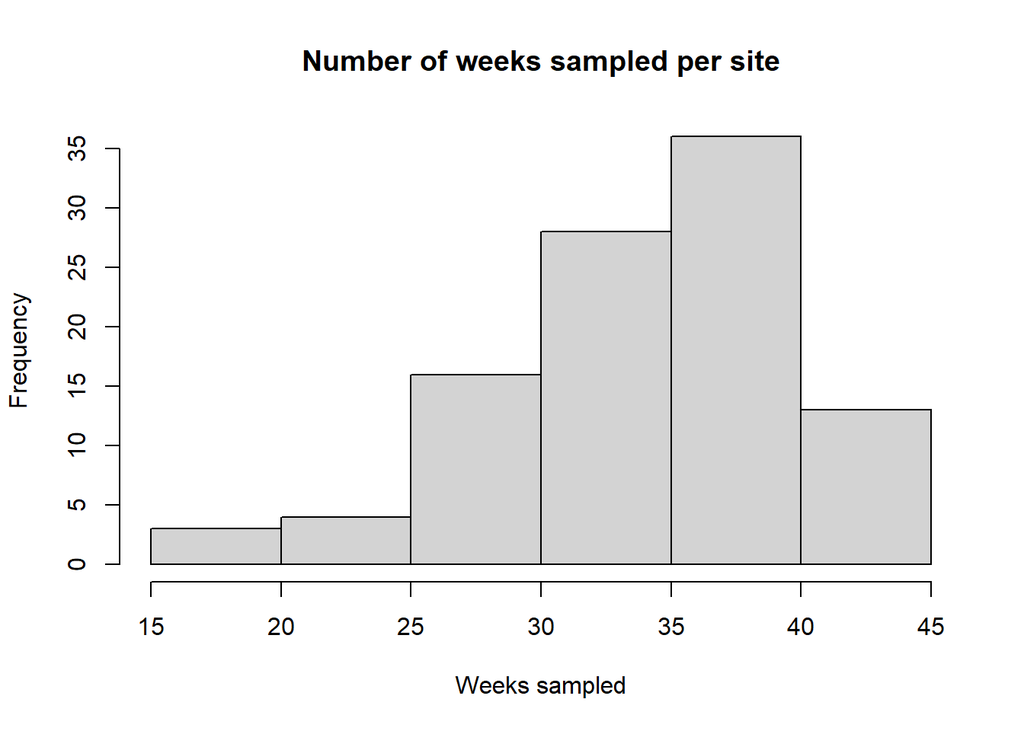

```r
nweeks_sampled <- apply(
  X = coyote,
  MARGIN = 1,
  function(x){
    sum(!is.na(x))
  }
)

# Check out a little histogram of this
hist(
  nweeks_sampled,
  main = "Number of weeks sampled per site",
  xlab = "Weeks sampled"
)
```

Now that we have the detection data formatted. It is time to read in the covariate data. The `autoOcc` package can handle covariates that vary spatially, temporally, or spatiotemporally. For this tutorial we are going to have two spatial covaraites and one spatiotemporal covariate. Thes are:

- An urban intensity metric we will generate with a principal components analysis
- The distance of each site to a stream or river
- The average weekly temperature of each week of sampling

One thing that is very important to remember is that unlike the detection data, the covariates CANNOT have missing data (i.e., `NA` values).

To read in the spatial covariates, copy this code here:

```r
covs <- read.csv(
  "./data/coyote_covariates.csv"
)

dplyr::glimpse(covs)
```

```
## Rows: 100
## Columns: 5
## $ Site            <chr> "C04-MBP1", "C05-BMP1", "C05-BMP2", "C06-HMP1", "D02-B…
## $ tree            <dbl> 0.289, 0.123, 0.111, 0.130, 0.105, 0.213, 0.175, 0.166…
## $ imperv          <dbl> 0.365, 0.087, 0.149, 0.220, 0.723, 0.483, 0.543, 0.605…
## $ housing_density <dbl> 668.000, 0.295, 1.273, 0.942, 2459.586, 2968.107, 5425…
## $ dist_stream     <dbl> 2.783, 1.707, 2.730, 0.396, 4.219, 4.544, 4.565, 3.891…
```

This dataset has 100 rows (we have 100 sites worth of data) and five columns:

- `Site`: The site the covariates are associated to. This is ordered exactly the same is the `coyote` data, and site names are identical among the two datasets.
- `tree`: The proportion of tree cover within 1000m of a site. To be used for urban intensity PCA.
- `imperv`: The proportion of impervious cover within 1000m of a site. To be used for urban intensity PCA.
- `housing_density`: The number of houses per square km within 1000m of a site. To be used for urban intensity PCA.
- `dist_stream`: The distance of each site to a stream or river in km.

To generate the urban intensity term, we are going to use `dplyr` to select only the columns we need and then use the `prcomp()` function in base `R`.

```r
# make an urbanization metric with tree cover (tree), impervious
#  cover (imperv), and housing density (housing_density)

urb_pca <- covs %>%
  dplyr::select(tree, imperv, housing_density) %>%
  prcomp(., center = TRUE, scale = TRUE)

# The first thing we want to see is how much variance each
#  component explains
summary(urb_pca)
```

```
## Importance of components:
##                           PC1    PC2     PC3
## Standard deviation     1.4514 0.8112 0.48508
## Proportion of Variance 0.7022 0.2194 0.07843
## Cumulative Proportion  0.7022 0.9216 1.00000
```

The first principal component (PC1) explains about 70% of the variation in the data, so we will go ahead and use only that one. We can interpret this term by looking at the loadings associated to `urb_pca`. We are going to round them as well as we don’t need to see that many significant digits.

```r
round(
  urb_pca$rotation,
  2
)
```

```
##                   PC1   PC2   PC3
## tree            -0.55 -0.70  0.46
## imperv           0.64  0.01  0.77
## housing_density  0.54 -0.71 -0.44
```

### Challenge 2: Interpret PC1

The first principal component, which has one urban intensity value for each site, can be accessed via `urb_pca$x[,1]`. However, we don’t need to look at those to be able to interpret this, we only need the loadings above. What do you think they mean? In other words, what do positive values of `urb_pca$x[,1]` mean? What about negative values?

**Solution**

For `PC1` we see that the loadings, which are used to construct`urb_pca$x[,1]`, for `imperv` and `housing_density` are both positive, while `tree` is negative. This means that negative values of the `urb_pca` are locations high in tree cover whereas positive values of the `urb_pca` are locations high in impervious cover and housing density. So negative is more forested and positive is more urban.

The second covariate we have is the distance of each site to a stream or river. We included this one as riparian areas are often used a corridors for mammals. However, before we include it into our covariate data.frame for analysis we need to scale it (we set scale = `TRUE` when making the principal component term). Why do you scale covariates for an analysis? It makes it more likely for the statistical algorithms used in `autoOcc` to converge. Scaling also makes it so you can compare the magnitude of slope terms in your model. As our occupancy covariates do not have any spatio-temporal data, we can assemble our covariates in a `data.frame`.

```r
occ_covs <- data.frame(
  urb = urb_pca$x[,1], # the PC1 term.
  dist_stream = as.numeric(
    scale(
      covs$dist_stream
    )
  )
)
```

In addition to these covariate data, we also have weekly temperature data to include as a detection covariate. Since Chicago experiences four distinct seasons, coyote may alter their behavior when it’s either hot (the summer) or when its cold (the winter). This is also to show how to include survey-specific covariates on detection, which is something `autoOcc` can easily handle.

```r
week_temp <- read.csv(
  "./data/weekly_temp_data.csv"
)
dplyr::glimpse(week_temp)
```

```
## Rows: 8,100
## Columns: 4
## $ Site   <chr> "C04-MBP1", "C04-MBP1", "C04-MBP1", "C04-MBP1", "C04-MBP1", "C0…
## $ Season <chr> "JA18", "JA18", "JA18", "JA18", "JA18", "JA18", "JA18", "JA18",…
## $ Week   <chr> "Week_1", "Week_2", "Week_3", "Week_4", "Week_5", "Week_6", "We…
## $ temp   <dbl> 1.9714286, -13.1428571, -14.0285714, -1.1428571, -3.8571429, 3.…
```

You want to have the `data.frame` set up so all the data for each site is grouped together, and each grouping is arranged temporally from the beginning to the end of the study. Thus, this `data.frame` is set up to vary by week, season, and then site.

Before we arrange the data, let’s query some of the dimensions we are going to need to set it up.

```r
# right now the data are set up so it varies by week, season, and then site.
nweek <- dplyr::n_distinct(week_temp$Week)
nseason <- dplyr::n_distinct(week_temp$Season)
nsite <- dplyr::n_distinct(week_temp$Site)
```

To set up this covariate we are going to need to create a matrix with a number of rows equal to `nsite` and a number of columns equal to `nweek * nseason` the first `nweek` columns will be for the first season, then the next `nweek` are for season 2, etc., etc. So each row is going to hold all the temperature data for one site. Because of the way the ordering in week_temp (week, season, then site) we can just input the covariate and fill the `matrix` in the correct way by setting the `byrow` argument to `TRUE`.

## Challenge 3. Make the temperature matrix.

The paragraph right above challenge three has all the info you would need to correctly generate the `matrix` in `R`. Give it a go!

```r
# Solution is below
```

**Solution**

```r
temp_matrix <- matrix(
  week_temp$temp,
  ncol = nweek * nseason,
  nrow = nsite,
  byrow = TRUE
)
```

```r
temp_matrix <- (
  temp_matrix - mean(temp_matrix)
) / sd(temp_matrix)
```

Finally, we are also going to include urban intensity as a detection covariate. We are doing this because local abundance can influence detection probability, and coyote abundance likely covaries with urban intensity. Unlike the occupancy covariates, we will have one spatio-temporal covariate and one spatial covariate. Thus, we need to use a named `list` object for the detection covariates instead of a `data.frame`. If your detection covariates are only spatial in future analyses you can just use a `data.frame`.

```r
det_covs <- list(
  temp = temp_matrix,
  urb = occ_covs$urb
)
```

Back to table of contents ⤒

## 4. Fitting models

The `autoOcc` package was based on `unmarked`, so if you have any familiarity with `unmarked` you will find that the equation syntax is identically. If you are unfamiliar, for this model you need to specify two linear predictors to fit the model (detection then occupancy). Spefically, the `auto_occ()` function uses a double-right hand side formula, which means you do not need to specify what the response variable in the formula itself. For example, the syntax for an intercept only model would be `~1~1`.

For this workshop we are going to fit five models. There are certainly others that could be fitted with the supplied covariates, but this is a decent start. You will notice that all of our models include the same linear predictors for detection, included both linear and quadratic responses to urban intensity and weekly temperature. The main reason for this is just because we are not too interested in trying to determine the most parsimonious detection model and the AIC of these models can be quite sensitive to changes in detection covariates.

These models we will fit include:

- Occupancy does not covary with any covariates. The null. (`~1`)
- Occupancy is associated with urban intensity (`~urb`)
- Occupancy is associated with distance to a stream or river (`~dist_stream`)
- Occupancy is associated with both spatial covariates (`urb + dist_stream`)
- Occupancy is associated with both spatial covariates, and there is an interaction betwen the two (`urb * dist_stream`)

To fit an autologistic occupancy model you use the `autoOcc::auto_occ()` function. Go ahead and copy / paste this code into your script and run fit them all. Note that if you changed the names of any of the objects above you will also need to modify them here. Finally, note that I am using 85% confidence intervals here instead of the standard 95% most people use. Why? [It aligns more closely with the use of AIC](https://royalsocietypublishing.org/doi/full/10.1098/rspb.2023.1261).

But before we fit all the models, let’s fit the simplest and look at a summary of the output.

```r
# the null model
null <- auto_occ(
  ~temp + I(temp^2) + urb + I(urb^2)
  ~1, # detection linear predictor first, then occupancy
  y = coyote,
  occ_covs = occ_covs,
  det_covs = det_covs,
  level = 0.85 # Using 85% CI because it aligns more with the use of AIC
)

my_summary <- summary(null)
```

```
##
## Call:
## auto_occ(formula = ~temp + I(temp^2) + urb + I(urb^2) ~ 1, y = coyote,
##     det_covs = det_covs, occ_covs = occ_covs, level = 0.85)
##
##
## optim convergence code: 0
## optim iterations: 48
##
## Occupancy estimates:
##
##           parameter    Est    SE lower  upper        p
## 1 psi - (Intercept) -0.839 0.151 -1.06 -0.622 2.54e-08
## 2       psi - theta  2.244 0.309  1.80  2.689 3.83e-13
##
## Note: psi - theta is the autologistic term
##
## Detection estimates:
##
##           parameter     Est     SE   lower   upper        p
## 3 rho - (Intercept) -0.7927 0.0953 -0.9299 -0.6556 8.82e-17
## 4        rho - temp -0.1181 0.0533 -0.1948 -0.0414 2.67e-02
## 5   rho - I(temp^2)  0.0862 0.0464  0.0195  0.1529 6.29e-02
## 6         rho - urb -0.2476 0.0560 -0.3282 -0.1671 9.63e-06
## 7    rho - I(urb^2) -0.0750 0.0265 -0.1131 -0.0368 4.65e-03
##
## AIC: 2827.861
```

You can see above that we have summaries for both levels of the model here, and they are labeled. Furthermore, even though we specified no covariates for occupancy, it has two parameters associated to it: the intercept and this theta term. That second one is the temporal autologistic term which is always included in this model. Specifically, this model estimates that the model intercept is `-0.839` and the theta term is `2.245`, which is STRONGLY positive.

## Challenge 4. Have these numbers make sense.

These estimates are on the logit-scale. Calculate three things with these values

- Coyote occupancy if they were not present in the previous timestep
- Coyote occupancy if they were present in the previous timestep
- The expected occupancy over time

As a hint, the help file for the `auto_occ` function may have some information that is relevant.

**Solution**

```r
# If you want to hard code it
b0 <- -0.839
theta <- 2.245

# occupancy if not present at t-1
coy_occ <- plogis(b0)

# Occupancy if present at t
coy_occ_theta <- plogis(b0 + theta)

# Expected occupancy
coy_ex_occ <- coy_occ / (coy_occ + (1 - coy_occ_theta))

# Or, if you wanted to query the parameters from the summary output, which
#  is an s4 class in R.
psi_parms <- my_summary@psi

b0 <- my_summary@psi$Est[1]
theta <- my_summary@psi$Est[2]


# occupancy if not present at t-1
coy_occ <- plogis(b0)

# Occupancy if present at t
coy_occ_theta <- plogis(b0 + theta)

# Expected occupancy
coy_ex_occ <- coy_occ / (coy_occ + (1 - coy_occ_theta))
```

From here, let’s fit the remaining models. Go ahead and copy this code over to your R script and run them.

```r
# urban intensity model
urb <- auto_occ(
  ~temp + I(temp^2) + urb + I(urb^2)
  ~ urb,
  y = coyote,
  occ_covs = occ_covs,
  det_covs = det_covs,
  level = 0.85
)

# stream model
stream <- auto_occ(
  ~temp + I(temp^2) + urb + I(urb^2)
  ~ dist_stream,
  y = coyote,
  occ_covs = occ_covs,
  det_covs = det_covs,
  level = 0.85
)

# urban + stream
urb_stream <- auto_occ(
  ~temp + I(temp^2) + urb + I(urb^2)
  ~ urb + dist_stream,
  y = coyote,
  occ_covs = occ_covs,
  det_covs = det_covs,
  level = 0.85
)

# urban * stream (interaction model)
urb_stream_inxs <- auto_occ(
  ~temp + I(temp^2) + urb + I(urb^2)
  ~ urb*dist_stream,
  y = coyote,
  occ_covs = occ_covs,
  det_covs = det_covs,
  level = 0.85
)
```

Back to table of contents ⤒

## 5. Compare models

After fitting our models, it is time to compare their relative fit using AIC. As a reminder, information theoretic approaches like AIC do not ensure you top model is good, it just has a better relative fit than the other models in your model set. If you are interested in further reading about AIC, I would greatly encourage looking up [Arnold (2010)](https://wildlife.onlinelibrary.wiley.com/doi/abs/10.1111/j.1937-2817.2010.tb01236.x) and [Sutherland et al. (2024)](https://royalsocietypublishing.org/doi/full/10.1098/rspb.2023.1261).

To compare our models, we just need to use the `compare_models()` function in `autoOcc`. This function requires a list object that contains all the models in our model set. If the list is named, then those names will transfer over to the AIC table.

```r
coyote_models <- list(
  null = null,
  urb = urb,
  stream = stream,
  urb_stream = urb_stream,
  urb_stream_inxs = urb_stream_inxs
)

# digits = 2 to set number of significant digits
coyote_aic <- compare_models(
  model_list = coyote_models,
  digits = 2
)

# check out the results
coyote_aic
```

```
##             model npar     AIC delta AICwt cumltvWt
## 1             urb    8 2818.95  0.00  0.65     0.65
## 2      urb_stream    9 2820.95  2.00  0.24     0.89
## 3 urb_stream_inxs   10 2822.88  3.93  0.09     0.98
## 4          stream    8 2827.28  8.33  0.01     0.99
## 5            null    7 2827.86  8.91  0.01     1.00
```

Using 2 delta AIC is a cutoff, it appears that there is essentially one competitive model. If we wanted to entertain the `urb_stream` model, note that it is exactly 2 AIC from the best-fit model. As AIC goes up by 2 for each parameter in the model, the inclusion of the stream variable actually did nothing to further explain the data. Thus, the stream covariate is likely an uninformative parameter, meaning we may as well focus on just the `urb` model. Let’s take a peek.

```r
best_model <- summary(urb)
```

```
##
## Call:
## auto_occ(formula = ~temp + I(temp^2) + urb + I(urb^2) ~ urb,
##     y = coyote, det_covs = det_covs, occ_covs = occ_covs, level = 0.85)
##
##
## optim convergence code: 0
## optim iterations: 50
##
## Occupancy estimates:
##
##           parameter    Est     SE  lower  upper        p
## 1 psi - (Intercept) -0.834 0.1414 -1.037 -0.630 3.74e-09
## 2         psi - urb -0.248 0.0764 -0.358 -0.138 1.17e-03
## 3       psi - theta  2.033 0.3003  1.601  2.465 1.30e-11
##
## Note: psi - theta is the autologistic term
##
## Detection estimates:
##
##           parameter     Est     SE  lower   upper        p
## 4 rho - (Intercept) -0.7182 0.0973 -0.858 -0.5782 1.53e-13
## 5        rho - temp -0.1085 0.0538 -0.186 -0.0310 4.37e-02
## 6   rho - I(temp^2)  0.0800 0.0465  0.013  0.1470 8.55e-02
## 7         rho - urb -0.1494 0.0624 -0.239 -0.0595 1.67e-02
## 8    rho - I(urb^2) -0.0644 0.0275 -0.104 -0.0249 1.91e-02
##
## AIC: 2818.954
```

## Challenge 5 Interpret the model output:

1. As urban intensity goes up, what happens with coyote occupancy?
2. What had a greater effect on detection probability? Temperature or urban intensity?
3. Given the non-linear terms in the detection model, what do you think the relationship between temperature and detection looks like? What about with urban intensity and detection?

**Solution**

1. As urban intensity goes up, coyote occupancy goes down because the slope term is negative (-0.248).
2. Urban intensity likely had a greater influence on detection probability because the slope term `rho-urb` is more negative than `rho - temp`. However, there is some uncertainty here as the quadratic terms differ a lot. Chances are the only way we’ll really be able to figure this out is to plot the relationships.
3. Temperature has a negative linear term and a positive quadratic term. Thus, this relationship is negative but convex (goes up at the very low and high temperatures). Urban intensity has a negative linear term and a negative quadratic term. Thus, this relationship is negative but concave (slightly higher at intermediate levels of urban intensity).

Back to table of contents ⤒

## 6. Predicting & plotting model outputs

To do this, we need to generate a new data.frame with all the associated covariates tied to a given level of the model (i.e., occupancy or detection). However, we scaled our covariates, and to generate our predictions they need to be scaled EXACTLY as the data we supplied to the model. In our case, this is pretty easy. The urban intensity covariate is already kind of abstract, so we just need to generate a sequence of values from around the same extent as the data we supplied. Following this, `autoOcc` has it’s own predict function, and it’s help file can be looked up with `?predict.auto_occ_fit`.

One unique aspect with making these model predictions is that this function derives the expected occupancy (see `?auto_occ` for more details). It does so through some simulations, and so if you want to return the exact same values each time it is a good idea to set a seed. The output of `predict` returns a data.frame with three columns: `estimate`, `lower`, and `upper` which respectively represent the mean estimate and the lower and upper confidence intervals.

```r
# Look up the range
range(occ_covs$urb)
```

```
## [1] -3.417673  4.558160
```

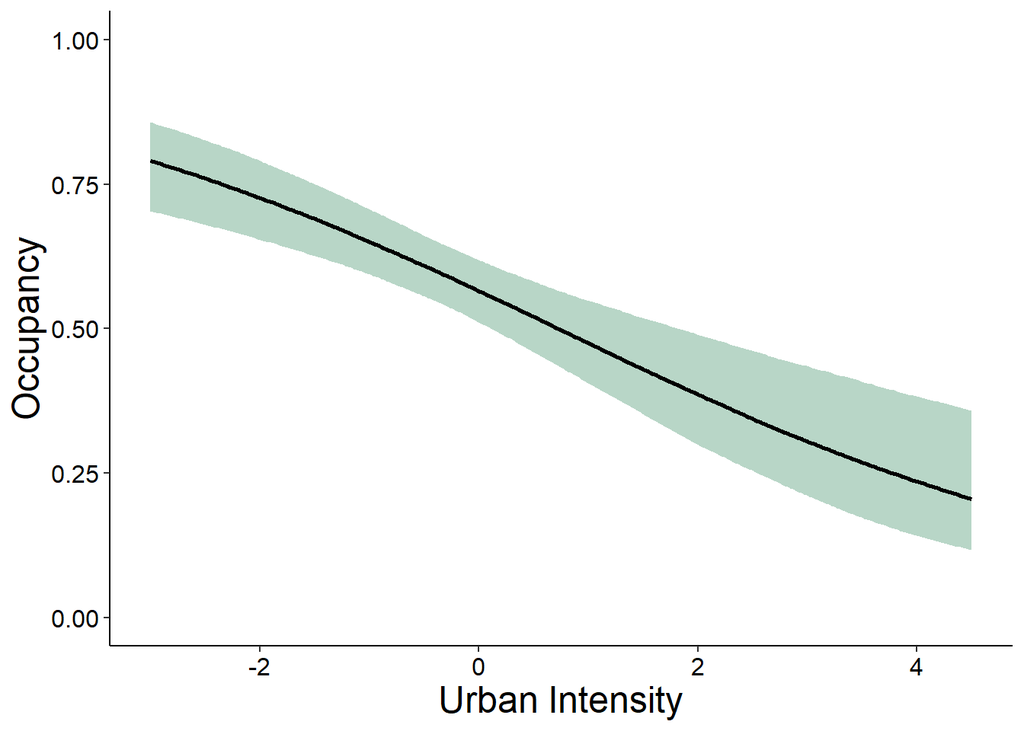

```r
# great data.frame for new predictions
occ_pred_df <- data.frame(
  urb = seq(-3, 4.5, length.out = 300)
)

# for help, see ?autoOcc::predict.auto_occ_fit
occ_preds <- predict(
  object = urb,
  type = "psi",
  newdata = occ_pred_df,
  level = 0.85,
  seed = 153
)

# add the urbanization covariate onto the predicions.
urb_plot <- data.frame(
  urb = occ_pred_df$urb,
  occ_preds
)

# and plot this out with ggplot
ggplot(urb_plot, aes(x = urb, y = estimate)) +
  geom_ribbon(aes(ymin = lower, ymax = upper), fill = "#72AD8F", alpha = 0.5) +
  geom_path(linewidth = 1) + # adds line
  labs(x = "Urban Intensity", y = "Occupancy") +
  scale_x_continuous(limits = c(-3,4.5)) +
  ylim(0,1)+
  theme_classic()+ # drops gray background and grid
  theme(plot.title=element_text(size = 16, hjust=0.5), # centers titles
        axis.text.x = element_text(size = 12, color = "black"),
        axis.text.y = element_text(size = 12, color = "black"),
        axis.title = element_text(size = 18))
```

Plotting out the results for the detection part of the model is just a little more complex because this level of the model contains two covariates. To plot these out we are going to have to assess the marginal effect of each, which means we will vary one of the covariates while keeping the other at a constant value (the mean of that covariate). Because we have centered and scaled our continuous covaraites, their means are zero (which effectively removes them from the model prediction). Let’s plot out the temperature results, and then leave the urban intensity plot as the last challenge.

```r
# What is the range of temperatures?
range(week_temp$temp)
```

```
## [1] -16.42857  27.37143
```

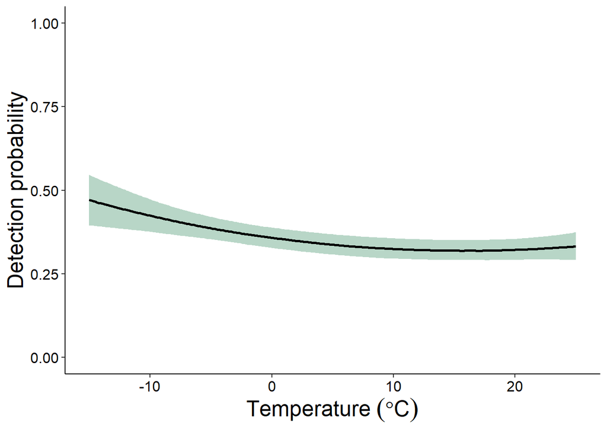

```r
# seems like somewhere between -15C and 25C is good for making
#  a 'pretty' x-axis
nice_temps <- seq(-15, 25, length.out = 300)
temp_pred_df <- data.frame(
  temp = nice_temps,
  urb = 0 # don't forget to include urb here!
)

# scale the temperature data like we did for our model
temp_pred_df$temp <- (temp_pred_df$temp - mean(week_temp$temp)) / sd(week_temp$temp)


# Generate predictions, this time switching type to 'rho' because it
#  is for detection probability.
det_temp_preds <- predict(
  object = urb,
  type = "rho",
  newdata = temp_pred_df,
  level = 0.85,
  seed = 154
)

# add temps into the data.frame for plotting purposes
det_temp_plot <- data.frame(
  temp = nice_temps,
  det_temp_preds
)

# An expression to get the degrees symbol for the x-axis
xlab_expression <- expression(
  Temperature~(degree*C)
)
# and plot this out with ggplot
ggplot(det_temp_plot, aes(x = temp, y = estimate)) +
  geom_ribbon(aes(ymin = lower, ymax = upper), fill = "#72AD8F", alpha = 0.5) +
  geom_path(linewidth = 1) + # adds line
  labs(x = xlab_expression, y = "Detection probability") +
  scale_x_continuous(limits = range(nice_temps)) +
  ylim(0,1)+
  theme_classic()+ # drops gray background and grid
  theme(plot.title=element_text(size = 16, hjust=0.5), # centers titles
        axis.text.x = element_text(size = 12, color = "black"),
        axis.text.y = element_text(size = 12, color = "black"),
        axis.title = element_text(size = 18))
```

## Challenge 6: Make the urban intensity detection figure

Hint: You should be able to piece together the code to do this from the last two figures.

**Solution**

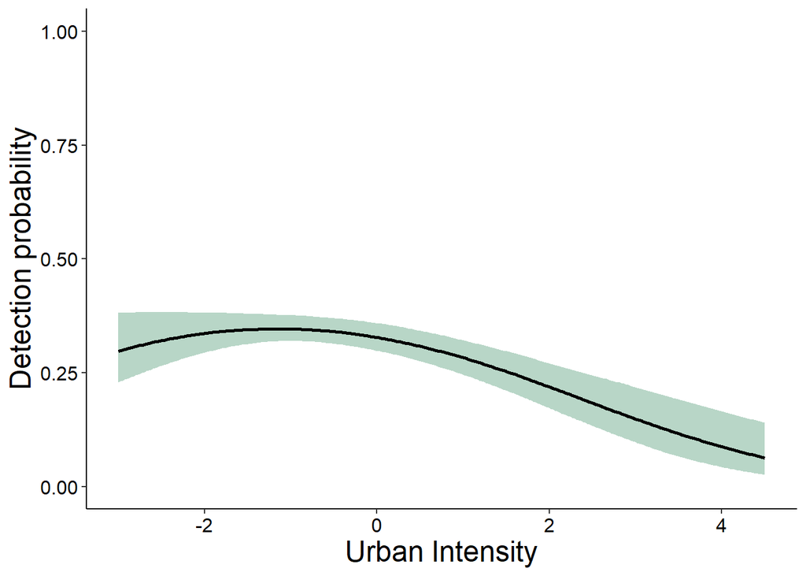

```r
urb_pred_df <- data.frame(
  temp = 0,
  urb = occ_pred_df$urb
)

det_urb_preds <- predict(
  object = urb,
  type = "rho",
  newdata = urb_pred_df,
  level = 0.85,
  seed = 154
)

det_urb_plot <- data.frame(
  urb = urb_pred_df$urb,
  det_urb_preds
)


# and plot this out with ggplot
ggplot(det_urb_plot, aes(x = urb, y = estimate)) +
  geom_ribbon(aes(ymin = lower, ymax = upper), fill = "#72AD8F", alpha = 0.5) +
  geom_path(linewidth = 1) + # adds line
  labs(x = "Urban Intensity", y = "Detection probability") +
  scale_x_continuous(limits = range(det_urb_plot$urb)) +
  ylim(0,1)+
  theme_classic()+ # drops gray background and grid
  theme(plot.title=element_text(size = 16, hjust=0.5), # centers titles
        axis.text.x = element_text(size = 12, color = "black"),
        axis.text.y = element_text(size = 12, color = "black"),
        axis.title = element_text(size = 18))
```

Back to table of contents ⤒